# QC Notes, Transcriptomics Data, 1st Alignment, Final QC

# Mapping indicators

## Introduction

This corresponds to the quality control analysis of metatranscriptomics data. The alignment is performed against the personal genomic references used for the alignment of metagenomics data. Counting is performed at the CDS level.

### Basic mapping stats

Data from the aligner (`bowtie2`) log files. These are ordered by total number of paired end reads per timepoint.

| Timep | S.tot | S.1 | S.mul | S.0 | map.se | Sample |
| --- | --- | --- | --- | --- | --- | --- |
| C3011.CSM67UEW | 25720 | 3707 | 13270 | 8743 | 0.66007 | C3011 |
| C3011.CSM7KOMP | 33767 | 4981 | 21473 | 7313 | 0.78343 | C3011 |
| C3012.CSM7KON8 | 119287 | 27276 | 84548 | 7463 | 0.93744 | C3012 |
| P6028.PSM7J177 | 647317 | 145324 | 421720 | 80273 | 0.87599 | P6028 |
| H4019.HSM7J4PK | 717613 | 4611 | 32607 | 680395 | 0.05186 | H4019 |
| M2026.MSM6J2OP | 762935 | 147349 | 575816 | 39770 | 0.94787 | M2026 |
| P6028.PSM7J17B | 809985 | 133265 | 461664 | 215056 | 0.73449 | P6028 |
| M2008.MSM5LLDI | 1088594 | 169896 | 817814 | 100884 | 0.90733 | M2008 |
| P6028.PSM7J163 | 1141843 | 185161 | 702148 | 254534 | 0.77708 | P6028 |
| C3013.CSM7KONU | 1251869 | 212759 | 740077 | 299033 | 0.76113 | C3013 |

[output cut: 711 more lines]

In this table:

[output not shown]

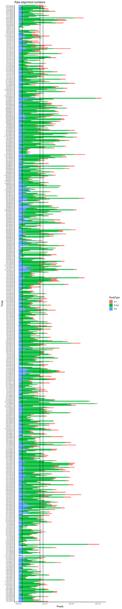

Mapping of metatranscriptomics data is towards a sample-specific metagenomic reference containing all species ever identified for all time points of this individual, coming from MetaSpades (Huttenhower).

### Summarised by individual

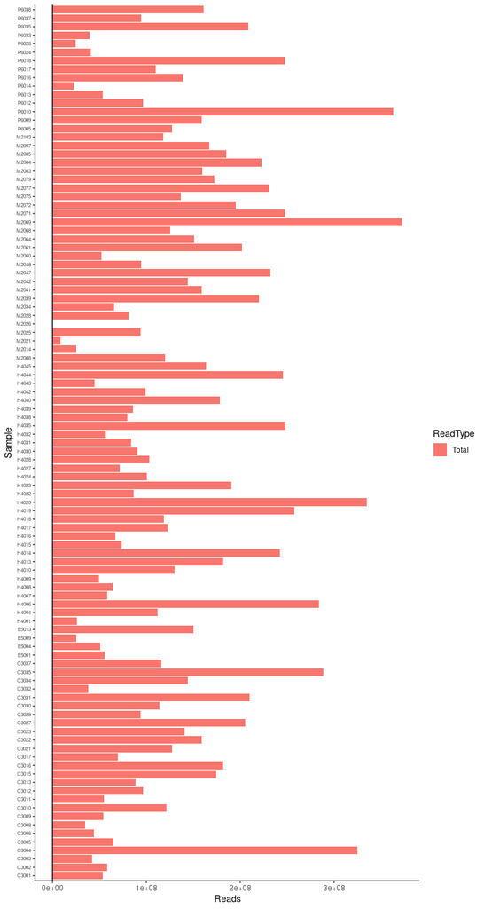

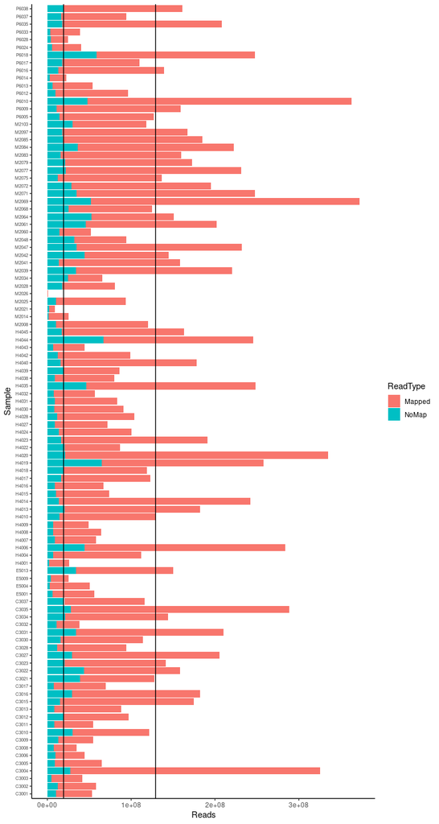

### Data from the feature counting (`subread featurecounts`)

(Uses data from BAM file, should be essentially same as previous)

This graph shows absolute number of mapped reads counted towards ORF / CDS at each timepoint for all individuals. The solid lines are the mean read counts across all.

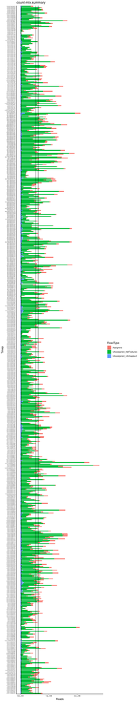

The following graph shows the relative distribution of mapped reads (the non-plotted fraction to 100% are ambiguously mapped reads).

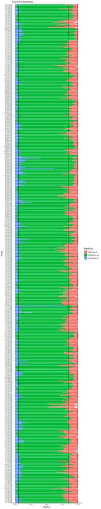

### Summary per individual

Total number of mapped reads:

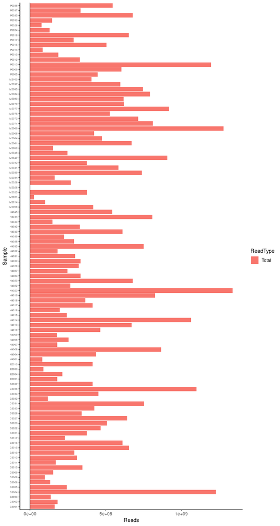

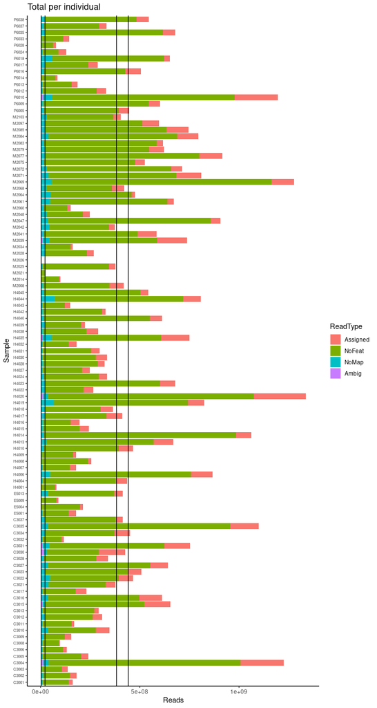

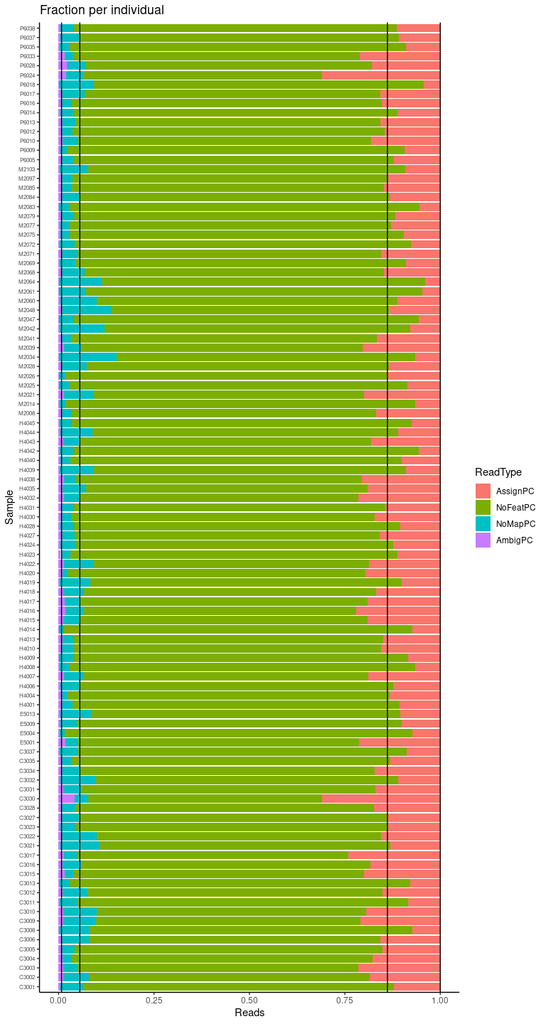

### Sample / Timepoint exclusion for low read count

Transcriptomics data does not have an acute low read count problem, though some timepoints have comparatively low counts.

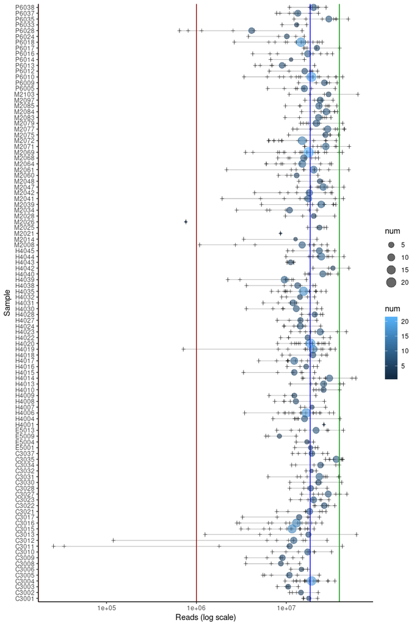

The number of timepoints versus total read count is as follows (only the lower read count region shown). The low read count timepoints are the first rows of the table at the top of this document, but annotated here anyway.

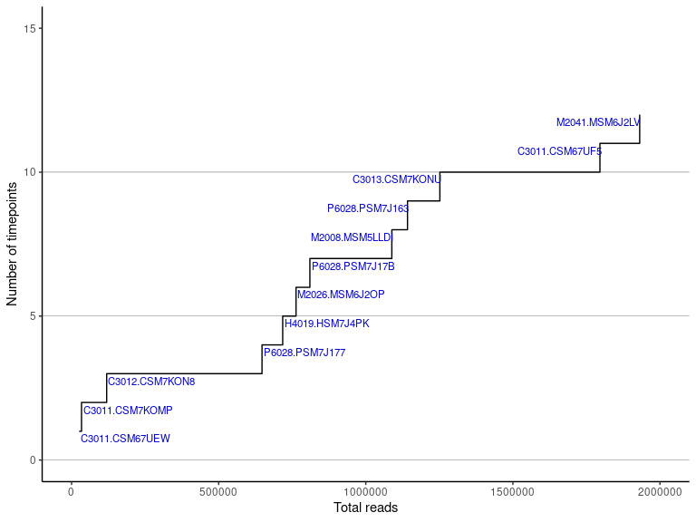